# Homework 7

Carmen Canedo

27 November 2020

# Keys

*Primary keys* uniquely identify an observation within its own table. *Foreign keys* uniquely identify an observation in another table.

To be sure the identification is unique, count the primary keys and see if any are greater than 1.

There is not a primary key in the flights tibble because the values repeat. We need to add a *surrogate key* to flights.

## Exercise 1 Identify the primary keys in three datasets.

Be sure to show that you have the primary key by showing there are no duplicate entries.

### a. Lahman Batting Primary Key

| playerID | stint | yearID | n |
| --- | --- | --- | --- |

The primary key for `Lahman::Batting` is `playerID`, `stint`, and `yearID`.

### b. Babynames Primary key

The primary key for `babynames` is `name`, `year`, and `sex`.

### c. Atmos Primary Key

| lat | long | year | month | n |
| --- | --- | --- | --- | --- |

the primary key for `atmos` is `lat`, `long`, `year`, `month`.

## Exercise 2 What is the relationship between the Batting, Master, and Salaries tables in the Lahman package? What are the keys for ech dataset and how do they relate to each other?

| playerID | n |
| --- | --- |

| playerID | teamID | yearID | n |
| --- | --- | --- | --- |

As we know from above, the primary key for `Batting` is `playerID`, `stint`, and `yearID`. The primary key for `Master` is `playerID`, and for `Salaries` it is `playerID`, `teamID`, and `yearID`.

`playerID` in `Master` has a 1 to many relationship in Salaries and Batting.

# Mutating Joins

*Inner Joins* connect pairs of observations when their keys are equal. Unmatched rows will not be included in the result.

*Outer Joins* keep observations that appear in at least one of the tables:

- `left_join(x, y)` keeps all observations in `x`
- `right_join(x, y)` keeps all observations in `y`
- `full_join(x, y)` keeps all observations

*Natural join* is the default and uses all variables with the same name in both tables.

Using `by = "variable_name` joins by specified variables only.

You can also use `by = c("variable_a" = "variable_b")` to use a key with a different name in each table

## Exercise 3 Use an appropriate join to add a column containing the airline name to the flights dataset.

Be sure to put the carrier code and name in the first two columns of the result. **Save as `flights2`**

| carrier | name | year | month | day | dep_time | sched_dep_time | dep_delay | arr_time | sched_arr_time | arr_delay | flight | tailnum | origin | dest | air_time | distance | hour | minute | time_hour |
| --- | --- | --- | --- | --- | --- | --- | --- | --- | --- | --- | --- | --- | --- | --- | --- | --- | --- | --- | --- |
| UA | United Air Lines Inc. | 2013 | 1 | 1 | 517 | 515 | 2 | 830 | 819 | 11 | 1545 | N14228 | EWR | IAH | 227 | 1400 | 5 | 15 | 2013-01-01 05:00:00 |
| UA | United Air Lines Inc. | 2013 | 1 | 1 | 533 | 529 | 4 | 850 | 830 | 20 | 1714 | N24211 | LGA | IAH | 227 | 1416 | 5 | 29 | 2013-01-01 05:00:00 |
| AA | American Airlines Inc. | 2013 | 1 | 1 | 542 | 540 | 2 | 923 | 850 | 33 | 1141 | N619AA | JFK | MIA | 160 | 1089 | 5 | 40 | 2013-01-01 05:00:00 |
| B6 | JetBlue Airways | 2013 | 1 | 1 | 544 | 545 | -1 | 1004 | 1022 | -18 | 725 | N804JB | JFK | BQN | 183 | 1576 | 5 | 45 | 2013-01-01 05:00:00 |
| DL | Delta Air Lines Inc. | 2013 | 1 | 1 | 554 | 600 | -6 | 812 | 837 | -25 | 461 | N668DN | LGA | ATL | 116 | 762 | 6 | 0 | 2013-01-01 06:00:00 |
| UA | United Air Lines Inc. | 2013 | 1 | 1 | 554 | 558 | -4 | 740 | 728 | 12 | 1696 | N39463 | EWR | ORD | 150 | 719 | 5 | 58 | 2013-01-01 05:00:00 |
| B6 | JetBlue Airways | 2013 | 1 | 1 | 555 | 600 | -5 | 913 | 854 | 19 | 507 | N516JB | EWR | FLL | 158 | 1065 | 6 | 0 | 2013-01-01 06:00:00 |
| EV | ExpressJet Airlines Inc. | 2013 | 1 | 1 | 557 | 600 | -3 | 709 | 723 | -14 | 5708 | N829AS | LGA | IAD | 53 | 229 | 6 | 0 | 2013-01-01 06:00:00 |
| B6 | JetBlue Airways | 2013 | 1 | 1 | 557 | 600 | -3 | 838 | 846 | -8 | 79 | N593JB | JFK | MCO | 140 | 944 | 6 | 0 | 2013-01-01 06:00:00 |
| AA | American Airlines Inc. | 2013 | 1 | 1 | 558 | 600 | -2 | 753 | 745 | 8 | 301 | N3ALAA | LGA | ORD | 138 | 733 | 6 | 0 | 2013-01-01 06:00:00 |

[output cut: 990 more lines]

## Exercise 4 Use an appropriate join to add the airport name to the `flights2` dataset.

The codes and names of the airports are in the airports dataset of `nycflights13` package.

| carrier | name | origin | airport_origin | dest | airport_dest | year | month | day | dep_time | sched_dep_time | dep_delay | arr_time | sched_arr_time | arr_delay | flight | tailnum | air_time | distance | hour | minute | time_hour |
| --- | --- | --- | --- | --- | --- | --- | --- | --- | --- | --- | --- | --- | --- | --- | --- | --- | --- | --- | --- | --- | --- |
| UA | United Air Lines Inc. | EWR | Newark Liberty Intl | IAH | George Bush Intercontinental | 2013 | 1 | 1 | 517 | 515 | 2 | 830 | 819 | 11 | 1545 | N14228 | 227 | 1400 | 5 | 15 | 2013-01-01 05:00:00 |
| UA | United Air Lines Inc. | LGA | La Guardia | IAH | George Bush Intercontinental | 2013 | 1 | 1 | 533 | 529 | 4 | 850 | 830 | 20 | 1714 | N24211 | 227 | 1416 | 5 | 29 | 2013-01-01 05:00:00 |
| AA | American Airlines Inc. | JFK | John F Kennedy Intl | MIA | Miami Intl | 2013 | 1 | 1 | 542 | 540 | 2 | 923 | 850 | 33 | 1141 | N619AA | 160 | 1089 | 5 | 40 | 2013-01-01 05:00:00 |
| B6 | JetBlue Airways | JFK | John F Kennedy Intl | BQN | NA | 2013 | 1 | 1 | 544 | 545 | -1 | 1004 | 1022 | -18 | 725 | N804JB | 183 | 1576 | 5 | 45 | 2013-01-01 05:00:00 |
| DL | Delta Air Lines Inc. | LGA | La Guardia | ATL | Hartsfield Jackson Atlanta Intl | 2013 | 1 | 1 | 554 | 600 | -6 | 812 | 837 | -25 | 461 | N668DN | 116 | 762 | 6 | 0 | 2013-01-01 06:00:00 |
| UA | United Air Lines Inc. | EWR | Newark Liberty Intl | ORD | Chicago Ohare Intl | 2013 | 1 | 1 | 554 | 558 | -4 | 740 | 728 | 12 | 1696 | N39463 | 150 | 719 | 5 | 58 | 2013-01-01 05:00:00 |
| B6 | JetBlue Airways | EWR | Newark Liberty Intl | FLL | Fort Lauderdale Hollywood Intl | 2013 | 1 | 1 | 555 | 600 | -5 | 913 | 854 | 19 | 507 | N516JB | 158 | 1065 | 6 | 0 | 2013-01-01 06:00:00 |
| EV | ExpressJet Airlines Inc. | LGA | La Guardia | IAD | Washington Dulles Intl | 2013 | 1 | 1 | 557 | 600 | -3 | 709 | 723 | -14 | 5708 | N829AS | 53 | 229 | 6 | 0 | 2013-01-01 06:00:00 |
| B6 | JetBlue Airways | JFK | John F Kennedy Intl | MCO | Orlando Intl | 2013 | 1 | 1 | 557 | 600 | -3 | 838 | 846 | -8 | 79 | N593JB | 140 | 944 | 6 | 0 | 2013-01-01 06:00:00 |
| AA | American Airlines Inc. | LGA | La Guardia | ORD | Chicago Ohare Intl | 2013 | 1 | 1 | 558 | 600 | -2 | 753 | 745 | 8 | 301 | N3ALAA | 138 | 733 | 6 | 0 | 2013-01-01 06:00:00 |

[output cut: 990 more lines]

# Filtering Joins

You can use *filter joins* to filter observations from one tibble based on whether or not they match an observation in another tibble.

A *semi join* between `x` and `y`:

- Keeps all observations in `x` that have a match in `y`
- Is useful for matchinf filtered summary back to original row

An *anti join* between `x` and `y` is the inverse of the semi join:

- *Drops* all observations in `x` that have a match in `y`
- Useful for diagnosing join mismatches

## Exercise 5 Compute the average delay by destination, then join the airports data frame so you can show the spatial distribution of delays.

- Use the size or color of the points to display the average delay for each airport.
- Add the location of the origin and destination (lat and lon) to flights
- Compute the average delay by destination

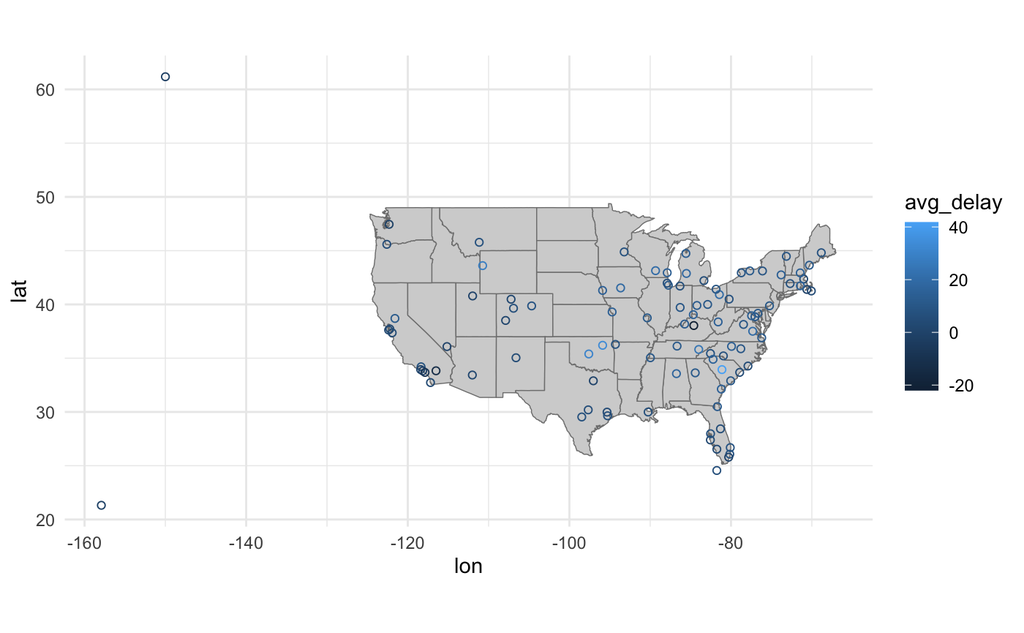

# Set Operations

`dplyr` provides functions for performing standard set operations:

- `intersect(x, y)` returns the intersection of datasets `x` and `y`
- `union(x, y)` returns the union of datasets `x` and `y`
- `setdiff(x, y)` returns set members in `x` that are not in `y`.

## Exercise 6 Use a set operation function to find which airport codes from flights are not in the airports datset

```
[1] "BQN" "SJU" "STT" "PSE"
```